# [W6] TextTextText

```r
library(readr)
library(dplyr)
library(stringr)
library(lattice)
```

# R 語言與資料科學導論作業 (W6)

一般系 b96001001 未命名

## Volatile Text (45%)

### CBOE Volatility Data

請到以下連結下載CBOE的[VIX Futures Settlements資料](https://goo.gl/Yb5UEJ) （資料來源：[Link](http://cfe.cboe.com/market-data/settlement/volatility-settlements)）。 這筆資料是個單純的文字檔，內容全部是英數文字。裡面有每週Settlement數值，請把這些資料變成一個data frame。接著，請以日期當橫軸，數值當縱軸做折線圖。

### 一、請將資料轉變為data frame。 (35%)

data frame應該有兩欄。第一欄是日期，第二欄是數值。第一筆數值的日期應該是10/11/2017，最後一筆則是8/5/2015。

#### 評分標準：

- 成功地將文字檔中的日期與數值資料擷取出來 (20%)
- 將資料格式化為data frame (10%)
- 資料按照日期（從最近到最舊）排序(5%)

```r
# your code goes here.
vix_text <- read_file("data/VIX_20171003.txt")
vix_lines <- strsplit(vix_text, "\n")[[1]]
vix_data <- lapply(vix_lines, function(ln){
    m <- regexec("\\((\\d+/\\d+/20\\d+)\\):([\\d\\.]+)", ln, perl=T)
    if(m[[1]][1] < 0) return(NULL)
    toks = regmatches(ln, m)[[1]]
    ret <- c(date=toks[2], settle=as.numeric(toks[3]))
    return(ret)
})
vix.df = as_tibble(do.call(rbind, vix_data))
vix.df$date <- as.Date(vix.df$date, "%m/%d/%Y")
vix.df$settle <- as.numeric(vix.df$settle)
vix.df <- vix.df[order(vix.df$date, decreasing=TRUE),]
print(vix.df)
```

```
## # A tibble: 89 x 2
##          date settle
##        <date>  <dbl>
##  1 2017-10-11   9.96
##  2 2017-10-04   9.61
##  3 2017-09-27   9.83
##  4 2017-09-13  10.71
##  5 2017-09-06  12.02
##  6 2017-08-30  12.03
##  7 2017-08-23  12.85
##  8 2017-08-09  11.97
##  9 2017-08-02  10.02
## 10 2017-07-26   9.10
## # ... with 79 more rows
```

### 二、請將該資料作折線圖。

#### 評分標準：

- 資料繪製成折線圖(10%)

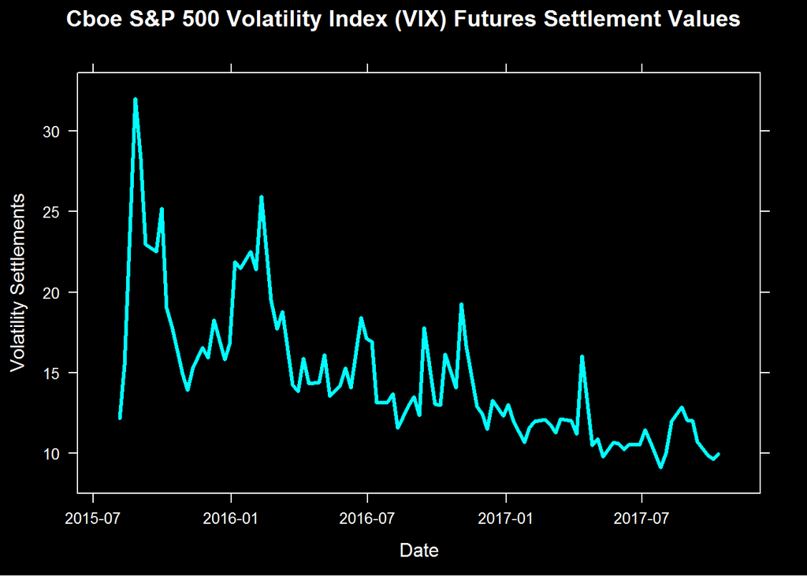

```r
# your code goes here.
xyplot(settle~date, data=vix.df,
       ty='l', par.settings=list(
           plot.line=list(lwd=3, col='cyan'),
           background=list(col="black"),
           axis.text=list(col="white"),
           axis.line=list(col="white"),
           axis.tick=list(col="white"),
           par.main.text=list(col="white"),
           par.ylab.text=list(col="white"),
           par.xlab.text=list(col="white")),
       xlab="Date", ylab="Volatility Settlements",
       main="Cboe S&P 500 Volatility Index (VIX) Futures Settlement Values")
```

## Collect the Runes (50%)

### 計算論語字頻表

請用以下連結下載[論語全文](https://raw.githubusercontent.com/RLadsNTU/RLadsLab/master/W6_TextTextText/data/confucius.txt)。這個檔案已經是個純文字檔，並用UTF-8編碼，所有標點符號都已經去除，但仍然有分行。 請您找出這個論語檔案中總共有幾個字，並有幾個不同的字，以及每個字的字頻。

### 一、製作字頻表 (35%)

#### 評分標準：

- 計算字頻 (10%)
- 將資料格式化為data frame (5%)

```r
# your code goes here.
conf_text <- read_file("data/confucius.txt")
conf_text <- gsub("\n", "", conf_text)
chtable <- table(strsplit(conf_text, ""))
chtable <- sort(chtable, decreasing=TRUE)
ntype <- length(chtable)
ntoken <- sum(chtable)
char.df <- as_tibble(chtable)
names(char.df) <- c("character", "frequency")
print(char.df)
```

```
## # A tibble: 1,361 x 2
##    character frequency
##        <chr>     <int>
##  1        子       979
##  2        曰       757
##  3        之       611
##  4        不       581
##  5        也       533
##  6        而       343
##  7        其       267
##  8        人       219
##  9        者       219
## 10        以       206
## # ... with 1,351 more rows
```

### 二、字頻表作圖 (15%)

#### 評分標準：

- 資料繪製成圖形(15%)

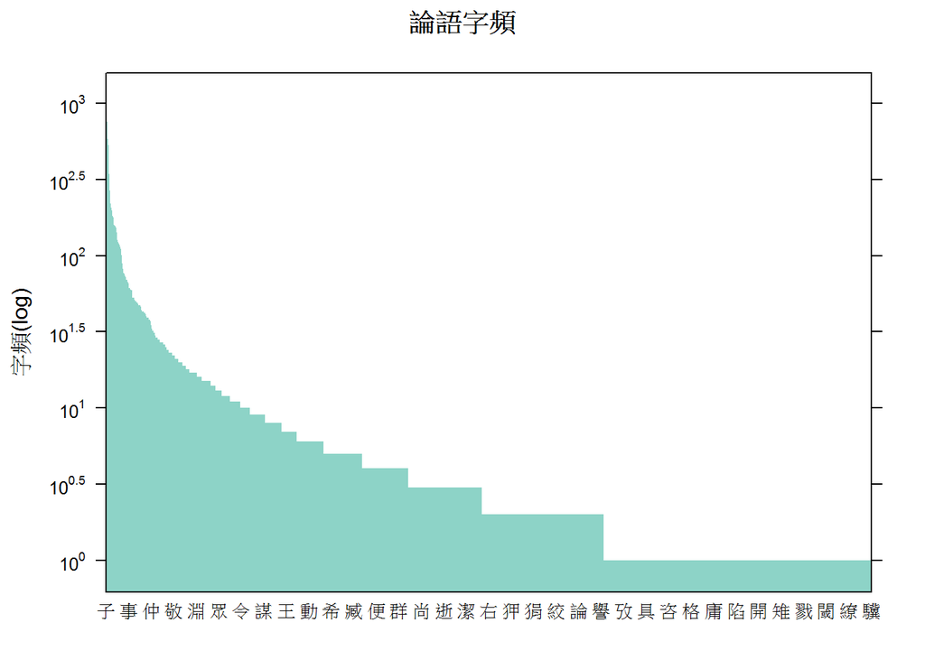

```r
# your code goes here.
char.df$fac_char = factor(char.df$character, ordered=TRUE, levels=char.df$character)
ytick <- seq(0, ceiling(log10(max(char.df$frequency))), 0.5)
barchart(frequency~fac_char, char.df,
         box.width=1.1,
         scales=list(
             y=list(log=T, at=10^ytick,
                    label=sapply(ytick, function(i) as.expression(bquote(10^.(i))))),
             x=list(at=xtick<-seq(1, nrow(char.df), 40),
                    labels=char.df$character[xtick])),
         par.settings=list(
             plot.polygon=list(col="#8DD3C7", border='transparent')
         ),
         ylab="字頻(log)", main='論語字頻')
```

## 進階選答題 (20%)

請用以下連結下載某一場中華職棒的比賽[文字記錄](https://goo.gl/XKrhxc)。裡面的內容分別是每一個半局每個打擊者的記錄。 當然，有很多細微的情境和動力很難從幾千個字中看出來， 但這個文字訊息裡，我們還是可以看到每個半局，有幾個打者上場打擊， 什麼時候有人出局，什麼時候有人上壘，什麼時候得分等等。 在這個練習中，請試著把每個半局，總共有幾棒打者上場的訊息擷取出來。 並把它整理成一個data.frame，最後請把這筆資料如以下方法視覺化的呈現出來。

#### 評分標準：

- 資料剖析(10%)
- 資料視覺化(10)

```r
# loading and parsing text
cpbl <- read_file("data/cpbl_20170929_235.play_by_play.txt")
innings <- strsplit(cpbl, "\\d[上下]")[[1]]
innings <- innings[-1]
labels = regmatches(cpbl, gregexpr("\\d[上下]", cpbl))[[1]]
bat.idx.vec <- gregexpr("\n\\d\\.", innings)
bat.n.vec <- sapply(bat.idx.vec, length)

# bulding and cleaning data.frame
df.nbat <- tibble(label=labels, nbat=bat.n.vec)
df.nbat <- df.nbat %>%
    mutate(
        inning = as.numeric(substr(labels, 1, 1)),
        half = substr(labels, 2, 2)
    )
df.nbat <- select(df.nbat, -label)
```

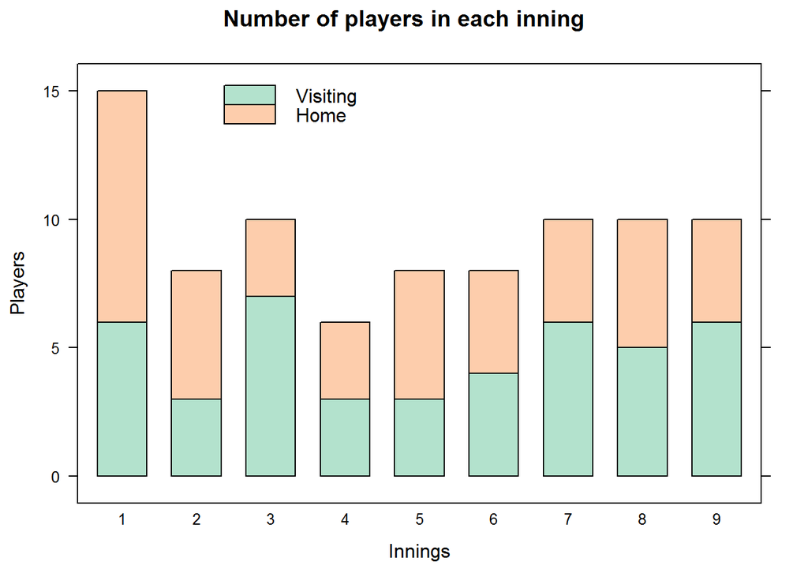

```r
## charting
barchart(nbat~inning, groups=half, data=df.nbat,
         bar.width = 0.8,
         stack=T, horizontal=F,
         xlab="Innings", ylab="Players", main='Number of players in each inning',
         key=list(rectangles=list(
                 col=RColorBrewer::brewer.pal(3, "Pastel2")[c(1,2)]),
                 text=list(c("Visiting", "Home")),
                 x=0.2, y=0.95),
         par.settings = list(
                 superpose.polygon=list(col=RColorBrewer::brewer.pal(3, "Pastel2"))))
```